# Primera pasada a variables de la Economía Popular

Taller de datos populares

5/13/2022

## Este notebook

Tomamos como referencia [este documento](https://docs.google.com/spreadsheets/d/1bNq4DF6C55rIMIrGOv5Z2_x0temKAeif/edit?usp=sharing&ouid=103738709450564223645&rtpof=true&sd=true), donde se indican una serie de variables a ser consideradas. En este notebook se realiza un analisis exploratorio de datos de ellas.

# Carga de datos

Para obtener los datos necesarios para el análisis, usamos el paquete de R que permite descargar datos de la EPH. Empezamos cargando el paquete, junto al paquete `tidyverse`, útil para realizar análisis de datos:

```r
library(tidyverse,warn.conflicts = FALSE,quietly = TRUE)
library(eph,warn.conflicts = FALSE,quietly = TRUE)
```

La función base que nos permite descargar información de la encuesta es `get_microdata`. En caso de querer explorar mejor las características del paquete, se sugiere revisar [este vignette](https://cran.r-project.org/web/packages/eph/vignettes/eph.html). Tomemos los datos del 3er trimestre de 2010:

```r
individual_10.3 <-get_microdata(year = 2010, trimester = 3,type='individual') # Vamos a llamar a los datasets siguiendo la notación type_year.trimester, como se ve acá.
individual_10.3
```

```
## # A tibble: 59,935 × 177
##    CODUSU NRO_HOGAR COMPONENTE   H15  ANO4 TRIMESTRE REGION MAS_500 AGLOMERADO
##    <chr>      <dbl>      <dbl> <dbl> <dbl>     <dbl>  <dbl> <chr>        <dbl>
##  1 301358         1          1     1  2010         3     43 S                2
##  2 304669         1          1     1  2010         3     43 S                2
##  3 304669         1          2     1  2010         3     43 S                2
##  4 304669         1          3     1  2010         3     43 S                2
##  5 302366         1          1     1  2010         3     43 S                2
##  6 129661         1          1     1  2010         3     43 S                2
##  7 132464         1          1     1  2010         3     43 S                2
##  8 132464         1          2     1  2010         3     43 S                2
##  9 132464         1          3     0  2010         3     43 S                2
## 10 235738         1          1     1  2010         3     43 S                2
## # … with 59,925 more rows, and 168 more variables: PONDERA <dbl>, CH03 <dbl>,
## #   CH04 <dbl>, CH06 <dbl>, CH07 <dbl>, CH08 <dbl>, CH09 <dbl>, CH10 <dbl>,
## #   CH11 <dbl>, CH12 <dbl>, CH13 <dbl>, CH14 <chr>, CH15 <dbl>, CH15_COD <int>,
## #   CH16 <dbl>, CH16_COD <int>, NIVEL_ED <dbl>, ESTADO <dbl>, CAT_OCUP <dbl>,
## #   CAT_INAC <dbl>, PP02C1 <dbl>, PP02C2 <dbl>, PP02C3 <dbl>, PP02C4 <dbl>,
## #   PP02C5 <dbl>, PP02C6 <dbl>, PP02C7 <dbl>, PP02C8 <dbl>, PP02E <dbl>,
## #   PP02H <dbl>, PP02I <dbl>, PP03C <dbl>, PP03D <dbl>, PP3E_TOT <dbl>, …
```

```r
rm(individual_10.3)
```

El paquete tiene algunos problemas a la hora de traer sólo parte de las variables (es decir, usando el argumento `vars` de `get_microdata`). A futuro, usaremos la base de datos localmente. De momento, nos conformaremos con descargar iterativamente toda la base y luego filtrar las columnas que nos interesen.

Para una descripción de las variables, mirar [este documento](https://www.indec.gob.ar/ftp/cuadros/menusuperior/eph/EPH_registro_4T2021.pdf) provisto por INDEC.

Construimos un vector con los nombres de las variables de interés, y descargamos iterativamente los datos de cada año, reteniendo únicamente la información asociada a estas variables:

```r
variables_de_interes <-
  c('ANO4','TRIMESTRE','REGION','AGLOMERADO',
    'CODUSU','NRO_HOGAR',
    'CH03','CH04','CH05',
    'ESTADO','CAT_OCUP','CAT_INAC',
    'PP04D_COD')
```

```r
trimester_final <- 1 # Último trimestre para el cual descargamos datos
year_final <- 2022 # Último año para el cuál descargamos datos
trimester <- 3 # Trimestre de inicio
year <- 2003 # Año de inicio

individual_03to22 <- NULL # Acá guardamos todo
while( year < year_final |
       (year == year_final & trimester < trimester_final)){

  df <- get_microdata(year = year, trimester = trimester,type='individual')
  if(nrow(df)>0){ # Checkeamos que tenga filas porque hay años faltantes
    individual_03to22 <- df %>% select(all_of(variables_de_interes)) %>% bind_rows(individual_03to22)
  }
  if(trimester == 4){
    print(paste(year,'COMPLETADO'))
    trimester <- 1
    year <- year + 1
  }else{
    trimester <- trimester + 1
  }

}
```

```
## [1] "2003 COMPLETADO"
## [1] "2004 COMPLETADO"
## [1] "2005 COMPLETADO"
## [1] "2006 COMPLETADO"
## [1] "2007 COMPLETADO"
## [1] "2008 COMPLETADO"
## [1] "2009 COMPLETADO"
## [1] "2010 COMPLETADO"
## [1] "2011 COMPLETADO"
## [1] "2012 COMPLETADO"
## [1] "2013 COMPLETADO"
## [1] "2014 COMPLETADO"
## [1] "2015 COMPLETADO"
## [1] "2016 COMPLETADO"
## [1] "2017 COMPLETADO"
## [1] "2018 COMPLETADO"
## [1] "2019 COMPLETADO"
## [1] "2020 COMPLETADO"
## [1] "2021 COMPLETADO"
```

```r
rm(df) # Borro lo que sobra
```

Veamos el dataset obtenido:

```r
individual_03to22
```

```
## # A tibble: 3,890,166 × 13
##     ANO4 TRIMESTRE REGION AGLOMERADO CODUSU   NRO_HOGAR  CH03  CH04 CH05  ESTADO
##    <dbl>     <dbl>  <dbl>      <dbl> <chr>        <dbl> <dbl> <dbl> <chr>  <dbl>
##  1  2021         4     44         17 TQRMNOP…         1     3     1 14/0…      3
##  2  2021         4      1         33 TQRMNOQ…         1     1     1 07/0…      3
##  3  2021         4      1         33 TQRMNOQ…         1     2     2 05/0…      3
##  4  2021         4      1         33 TQRMNOQ…         1     1     1 01/0…      1
##  5  2021         4     43          6 TQRMNOP…         1     2     2 01/0…      3
##  6  2021         4     40         23 TQRMNOQ…         1     1     2 19/0…      3
##  7  2021         4     40         23 TQRMNOQ…         1     3     1 27/0…      1
##  8  2021         4     44         17 TQRMNOP…         1     1     2 01/0…      3
##  9  2021         4     44         17 TQRMNOP…         1     3     2 01/0…      1
## 10  2021         4     44         17 TQRMNOP…         1     5     1 01/0…      4
## # … with 3,890,156 more rows, and 3 more variables: CAT_OCUP <dbl>,
## #   CAT_INAC <dbl>, PP04D_COD <chr>
```

## Nuevas variables

Construimos la variable `EDAD` a partir de la fecha de nacimiento y el año en el que se hizo la encuesta

```r
individual_03to22 <-
  individual_03to22 %>%
  mutate(FECHA_NAC = as.Date(CH05,format='%d/%m/%Y')) %>% # Pasamos la fecha de nacimiento a date
  mutate(FECHA_EPH = as.Date(paste(individual_03to22$ANO4,3*individual_03to22$TRIMESTRE,1),format='%Y %m %d')) %>% # Construimos la fecha en la que se hizo la encuesta
  mutate(EDAD = round(as.numeric(FECHA_EPH - FECHA_NAC)/365)) # Armamos la edad como la resta entre ambas dividido 365 días
```

# Análisis exploratorio

Habiendo reconstruido este dataset, exploremoslo

#### Distribución por regiones espaciales

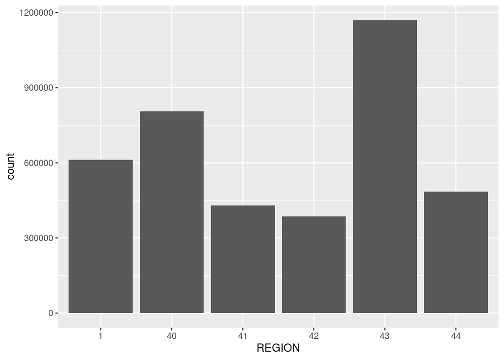

```r
individual_03to22 %>%
  mutate(REGION = factor(REGION)) %>%
  ggplot(aes(x=REGION)) + geom_bar(aes(y = ..count..))
```

La región pampeana es la más común (43), seguida por el NOA (40) y el GBA (1), luego la Patagonia (44), el NEA (41) y Cuyo (42).

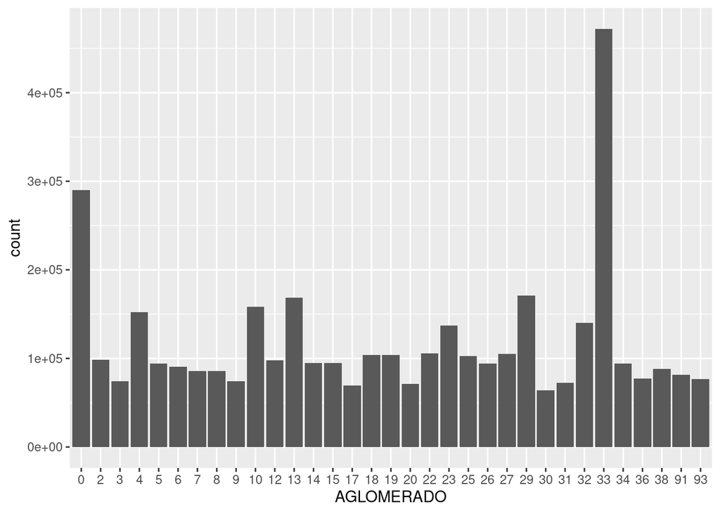

```r
individual_03to22 %>%
  mutate(AGLOMERADO = factor(AGLOMERADO)) %>%
  ggplot(aes(x=AGLOMERADO)) + geom_bar(aes(y = ..count..))
```

Cruzemos ambas variables

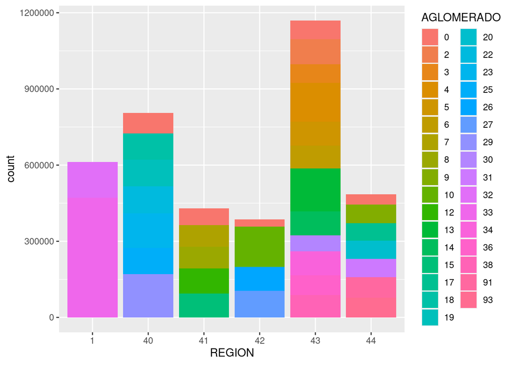

```r
individual_03to22 %>%
  mutate(REGION = factor(REGION)) %>%
  mutate(AGLOMERADO = factor(AGLOMERADO)) %>%
  ggplot(aes(x=REGION,fill=AGLOMERADO)) + geom_bar()
```

Algunos números:

Personas por REGION

```r
individual_03to22 %>%
  group_by(REGION) %>%
  summarise(PERSONAS_REGIONx1000 = n()/1e3) %>%
  select(PERSONAS_REGIONx1000) %>%
  summary()
```

```
##  PERSONAS_REGIONx1000
##  Min.   : 386.5
##  1st Qu.: 443.9
##  Median : 548.7
##  Mean   : 648.4
##  3rd Qu.: 757.7
##  Max.   :1169.9
```

Personas por AGLOMERADO

```r
individual_03to22 %>%
  group_by(AGLOMERADO) %>%
  summarise(PERSONAS_AGLOMERADOx1000 = n()/1e3) %>%
  select(PERSONAS_AGLOMERADOx1000) %>%
  summary()
```

```
##  PERSONAS_AGLOMERADOx1000
##  Min.   : 63.73
##  1st Qu.: 81.49
##  Median : 94.56
##  Mean   :117.88
##  3rd Qu.:105.60
##  Max.   :472.17
```

#### Distribución por características de las personas

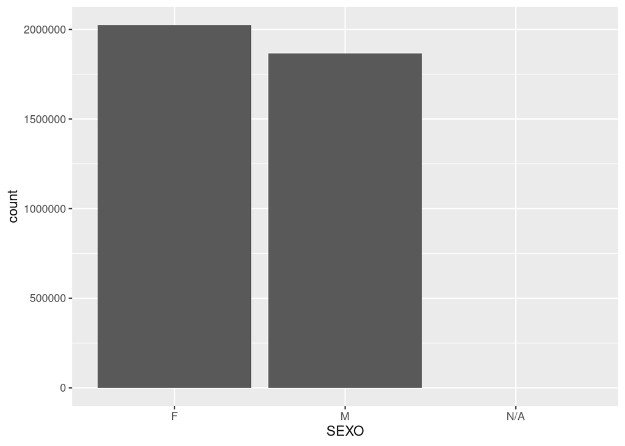

```r
individual_03to22 %>%
  mutate(SEXO = case_when(
    CH04 == 1 ~ 'M',
    CH04 == 2 ~ 'F',
    TRUE ~ 'N/A')) %>%
  ggplot(aes(x=SEXO)) + geom_bar()
```

Vemos que la población por género es similar, habiendo lévemente más mujeres que varones. Veamos la distribución por edad

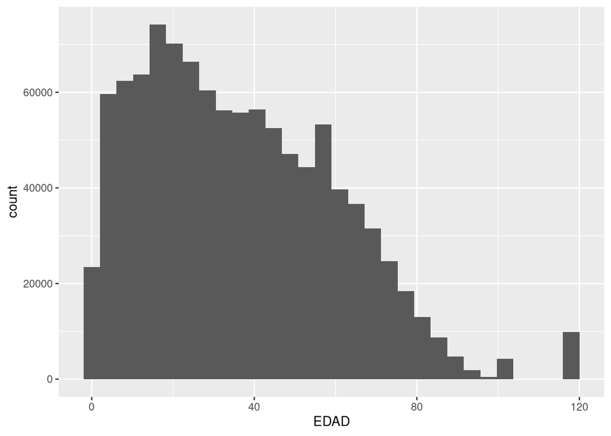

```r
individual_03to22 %>%
  filter(EDAD < 120 & EDAD > 0) %>%
  ggplot(aes(x=EDAD)) + geom_histogram()
```

```r
individual_03to22 %>%
summarise(EDAD_NEGATIVA = mean(EDAD<0,na.rm=TRUE)*100,
          EDAD_MAYOR100 = mean(EDAD>100,na.rm=TRUE)*100)
```

```
## # A tibble: 1 × 2
##   EDAD_NEGATIVA EDAD_MAYOR100
##           <dbl>         <dbl>
## 1         0.205          9.45
```

Veamos como se relaciona el SEXO con la EDAD

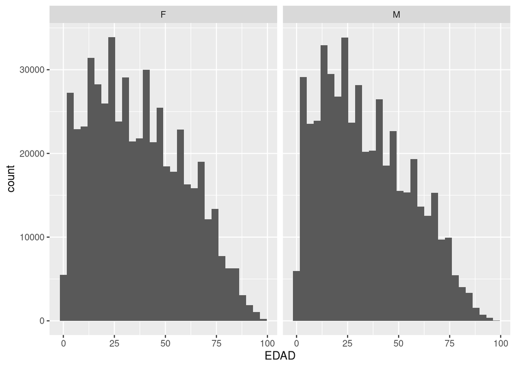

```r
individual_03to22 %>%
  filter(EDAD > 0 & EDAD < 100) %>%
  mutate(SEXO = case_when(
    CH04 == 1 ~ 'M',
    CH04 == 2 ~ 'F',
    TRUE ~ 'N/A')) %>%
  filter(SEXO != 'N/A') %>%
  ggplot(aes(x=EDAD)) +
  geom_histogram() + facet_wrap(facets = ~ SEXO )
```

Ambas distribuciones son muy similares.

#### Relación con aspectos laborales

Veamos como se relacionan la edad y el género con el rol de la persona en el hogar:

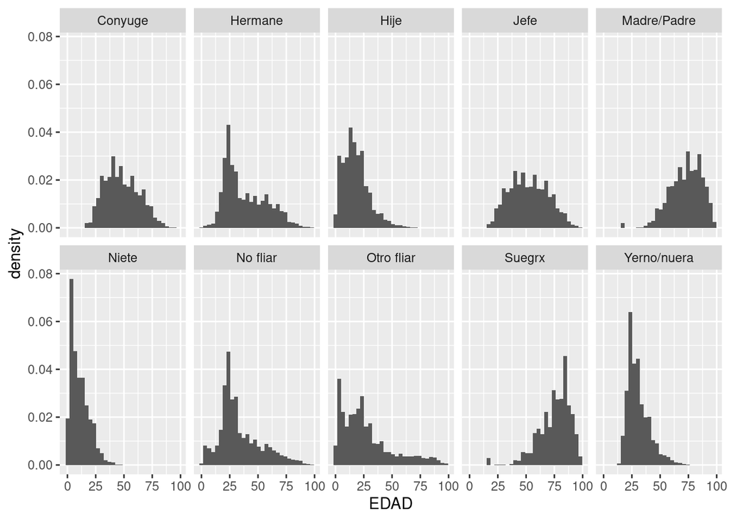

```r
individual_03to22 %>%
  filter(EDAD > 0 & EDAD < 100) %>%
  mutate(SEXO = case_when(
    CH04 == 1 ~ 'M',
    CH04 == 2 ~ 'F',
    TRUE ~ 'N/A')) %>%
  filter(SEXO != 'N/A') %>%
  mutate(ROL_HOGAR = case_when(
    CH03 == 1 ~ 'Jefe',
    CH03 == 2 ~ 'Conyuge',
    CH03 == 3 ~ 'Hije',
    CH03 == 4 ~ 'Yerno/nuera',
    CH03 == 5 ~ 'Niete',
    CH03 == 6 ~ 'Madre/Padre',
    CH03 == 7 ~ 'Suegrx',
    CH03 == 8 ~ 'Hermane',
    CH03 == 9 ~ 'Otro fliar',
    CH03 == 10 ~ 'No fliar',
    TRUE ~ 'N/A'
  )) %>%
  mutate(ROL_HOGAR = factor(ROL_HOGAR)) %>%
  ggplot(aes(x=EDAD)) +
  geom_histogram(aes(y = ..density..)) + facet_wrap(~ ROL_HOGAR,nrow=2)
```

Este gráfico tiene un montón de información sobre la edad de cada rol. Le jefe de familia está entre 25 y 75 años, conyugues sin hijes se concentran hacia los menores de 50, mientras que Madre/Padre a mayor de 50. Hermanes tienen pico en 25 años, y hijes por debajo de 25 años. Suegrxs concentran por arriba de 70 años y Yerno/Nuera en 25 años. Personas que no son de la familiar (probablemente casas de amigues) concentran en 25 años.

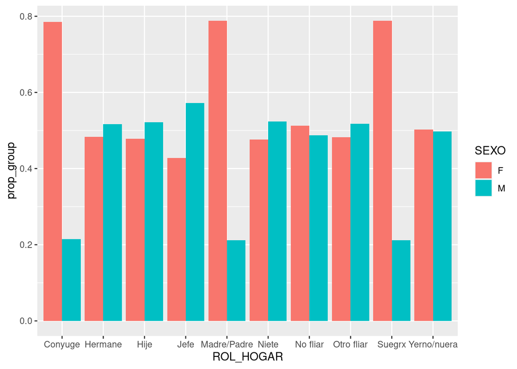

```r
individual_03to22 %>%
  filter(EDAD > 0 & EDAD < 100) %>%
  mutate(SEXO = case_when(
    CH04 == 1 ~ 'M',
    CH04 == 2 ~ 'F',
    TRUE ~ 'N/A')) %>%
  filter(SEXO != 'N/A') %>%
  mutate(ROL_HOGAR = case_when(
    CH03 == 1 ~ 'Jefe',
    CH03 == 2 ~ 'Conyuge',
    CH03 == 3 ~ 'Hije',
    CH03 == 4 ~ 'Yerno/nuera',
    CH03 == 5 ~ 'Niete',
    CH03 == 6 ~ 'Madre/Padre',
    CH03 == 7 ~ 'Suegrx',
    CH03 == 8 ~ 'Hermane',
    CH03 == 9 ~ 'Otro fliar',
    CH03 == 10 ~ 'No fliar',
    TRUE ~ 'N/A'
  )) %>%
  mutate(ROL_HOGAR = factor(ROL_HOGAR)) %>%
  group_by(ROL_HOGAR,SEXO) %>%
  summarize(count = n()) %>%
  group_by(ROL_HOGAR) %>%
  mutate(prop_group = count/sum(count) ) %>%
  ggplot(aes(x=ROL_HOGAR,y=prop_group)) +
  geom_col(aes(fill=SEXO),position='dodge')
```

Esto también es muy ilustrativo: Jefes del hogar suelen ser varones, y conyugues y madres/padres suelen ser mujeres. Hijes y Nietes son similares en cantidad. Nuevamente, se puede elaborar más.

Pongamos en relación con la categoría ocupación:

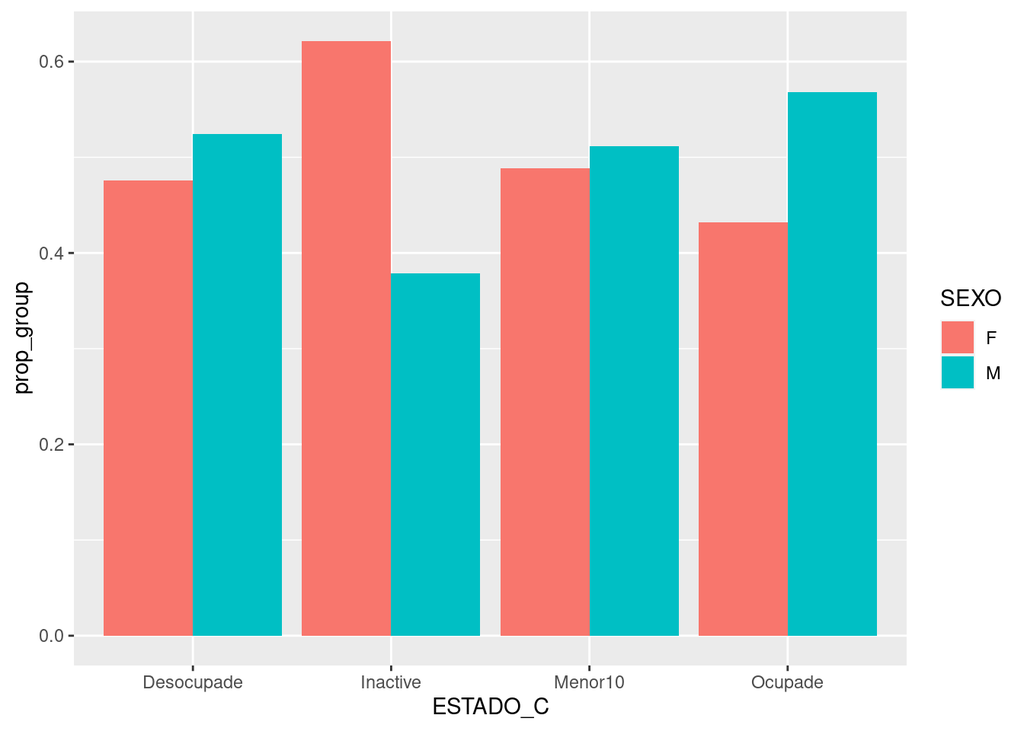

```r
individual_03to22 %>%
  filter(EDAD > 0 & EDAD < 100) %>%
  mutate(SEXO = case_when(
    CH04 == 1 ~ 'M',
    CH04 == 2 ~ 'F',
    TRUE ~ 'N/A')) %>%
  filter(SEXO != 'N/A') %>%
  mutate(ROL_HOGAR = case_when(
    CH03 == 1 ~ 'Jefe',
    CH03 == 2 ~ 'Conyuge',
    CH03 == 3 ~ 'Hije',
    CH03 == 4 ~ 'Yerno/nuera',
    CH03 == 5 ~ 'Niete',
    CH03 == 6 ~ 'Madre/Padre',
    CH03 == 7 ~ 'Suegrx',
    CH03 == 8 ~ 'Hermane',
    CH03 == 9 ~ 'Otro fliar',
    CH03 == 10 ~ 'No fliar',
    TRUE ~ 'N/A'
  )) %>%
  mutate(ESTADO_C = case_when(
    ESTADO == 1 ~ 'Ocupade',
    ESTADO == 2 ~ 'Desocupade',
    ESTADO == 3 ~ 'Inactive',
    ESTADO == 4 ~ 'Menor10',
    TRUE ~ 'N/A'
  )) %>%
  filter(ESTADO_C != 'N/A') %>%
  mutate(ESTADO_C = factor(ESTADO_C)) %>%
  mutate(ROL_HOGAR = factor(ROL_HOGAR)) %>%
  group_by(ESTADO_C,SEXO) %>%
  summarize(count = n()) %>%
  group_by(ESTADO_C) %>%
  mutate(prop_group = count/sum(count) ) %>%
  ggplot(aes(x=ESTADO_C,y=prop_group)) +
  geom_col(aes(fill=SEXO),position='dodge')
```

La personas ocupadas suelen ser varones y las personas inactivas mujeres. Menores de 10 años y Desocupades son similares.

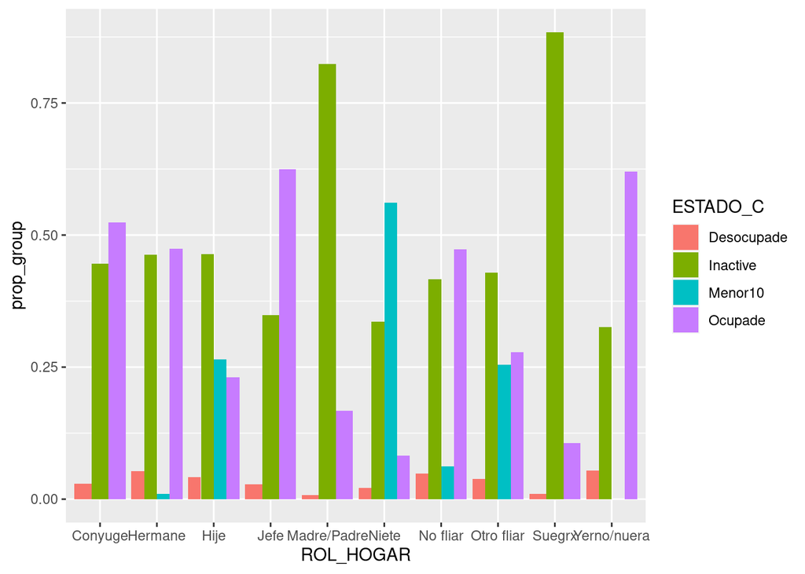

```r
individual_03to22 %>%
  filter(EDAD > 0 & EDAD < 100) %>%
  mutate(SEXO = case_when(
    CH04 == 1 ~ 'M',
    CH04 == 2 ~ 'F',
    TRUE ~ 'N/A')) %>%
  filter(SEXO != 'N/A') %>%
  mutate(ROL_HOGAR = case_when(
    CH03 == 1 ~ 'Jefe',
    CH03 == 2 ~ 'Conyuge',
    CH03 == 3 ~ 'Hije',
    CH03 == 4 ~ 'Yerno/nuera',
    CH03 == 5 ~ 'Niete',
    CH03 == 6 ~ 'Madre/Padre',
    CH03 == 7 ~ 'Suegrx',
    CH03 == 8 ~ 'Hermane',
    CH03 == 9 ~ 'Otro fliar',
    CH03 == 10 ~ 'No fliar',
    TRUE ~ 'N/A'
  )) %>%
  mutate(ESTADO_C = case_when(
    ESTADO == 1 ~ 'Ocupade',
    ESTADO == 2 ~ 'Desocupade',
    ESTADO == 3 ~ 'Inactive',
    ESTADO == 4 ~ 'Menor10',
    TRUE ~ 'N/A'
  )) %>%
  filter(ESTADO_C != 'N/A') %>%
  mutate(ESTADO_C = factor(ESTADO_C)) %>%
  mutate(ROL_HOGAR = factor(ROL_HOGAR)) %>%
  group_by(ESTADO_C,ROL_HOGAR) %>%
  summarize(count = n()) %>%
  group_by(ROL_HOGAR) %>%
  mutate(prop_group = count/sum(count) ) %>%
  ggplot(aes(x=ROL_HOGAR,y=prop_group)) +
  geom_col(aes(fill=ESTADO_C),position='dodge')
```

También un montón para elaborar acá: sólo rescatando algunas cosas: Madre/Padre suele ser inactive (probablemente las madres que vimos antes), al igual que Suegrx. Notablemente, Jefe suele ser Ocupade o Inactive.

# Variables de la Economía Popular

Construimos variables acorde a la tabla compartida:

```r
individual_03to22 <- individual_03to22 %>%
  mutate(ACTIVO_BIN = case_when(  # Variable ACTIVO_BIN
    ESTADO == 1 | ESTADO == 2 ~ 1, # 1 si está ocupado o descoupado
    TRUE ~ 0 # 0 si está inactivo o menor10
  )) %>%
  mutate(OCUPADO_BIN = case_when(  # Variable OCUPADO_BIN
    ESTADO == 1 | ESTADO == 2 ~ 1, # 1 si está ocupado
    TRUE ~ 0 # 0 si está inactivo o menor10 o desocupado
  )) %>%
  mutate(CUENTAPROPISTA_BIN = case_when(
    CAT_OCUP == 2 ~ 1,
    TRUE ~ 0
  )) #%>%
  # mutate(CUENTAPROPPROF_BIN = case_when( # Preguntar como se arma
  #   CUENTAPROPISTA_BIN == 1 & PP04D_COD == 1 ~ 1,
  #
  # ))
```

```r
individual_03to22 <- individual_03to22 %>%
  filter(EDAD > 0 & EDAD < 100) %>%
  mutate(SEXO = case_when(
    CH04 == 1 ~ 'M',
    CH04 == 2 ~ 'F',
    TRUE ~ 'N/A')) %>%
  filter(SEXO != 'N/A') %>%
  mutate(ROL_HOGAR = case_when(
    CH03 == 1 ~ 'Jefe',
    CH03 == 2 ~ 'Conyuge',
    CH03 == 3 ~ 'Hije',
    CH03 == 4 ~ 'Yerno/nuera',
    CH03 == 5 ~ 'Niete',
    CH03 == 6 ~ 'Madre/Padre',
    CH03 == 7 ~ 'Suegrx',
    CH03 == 8 ~ 'Hermane',
    CH03 == 9 ~ 'Otro fliar',
    CH03 == 10 ~ 'No fliar',
    TRUE ~ 'N/A'
  )) %>%
  mutate(ESTADO_C = case_when(
    ESTADO == 1 ~ 'Ocupade',
    ESTADO == 2 ~ 'Desocupade',
    ESTADO == 3 ~ 'Inactive',
    ESTADO == 4 ~ 'Menor10',
    TRUE ~ 'N/A'
  )) %>%
  filter(ESTADO_C != 'N/A') %>%
  mutate(ESTADO_C = factor(ESTADO_C)) %>%
  mutate(ROL_HOGAR = factor(ROL_HOGAR))
```

Veamos población cuentapropistas por género y edad

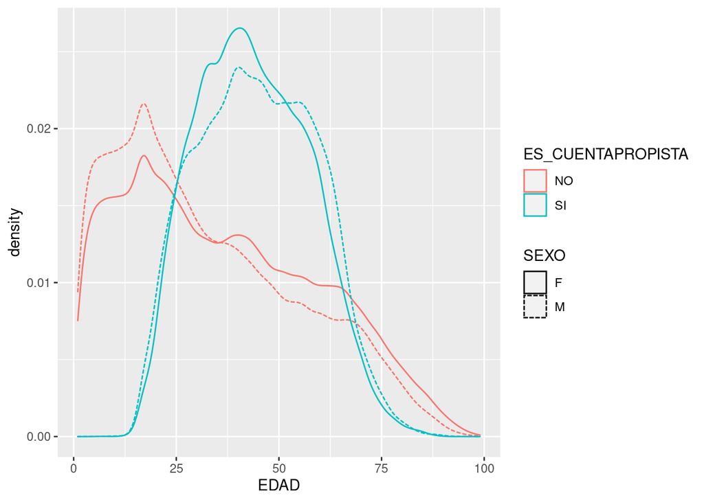

```r
individual_03to22 %>%
  mutate(ES_CUENTAPROPISTA = ifelse(CUENTAPROPISTA_BIN==1,'SI','NO')) %>%
  ggplot(aes(x=EDAD,color=ES_CUENTAPROPISTA,linetype = SEXO)) +
  geom_density()
```

Cuentapropismo en función del tiempo:

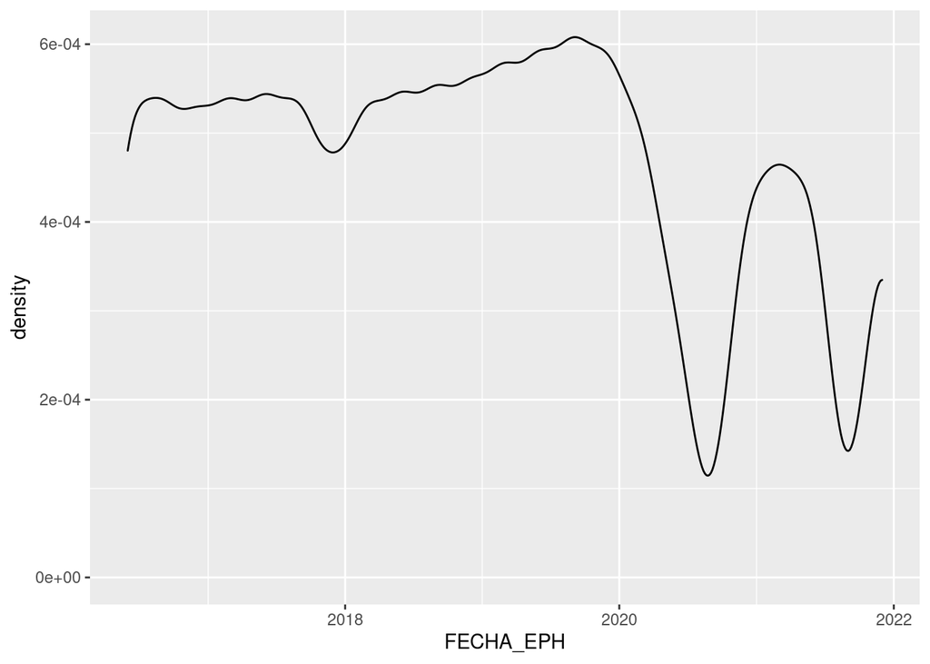

```r
individual_03to22 %>%
  filter(CUENTAPROPISTA_BIN ==1 ) %>%
  ggplot(aes(x=FECHA_EPH)) +
  geom_density()
```

¿Esta curva muestra es el resultado de la pandemia?

## Familia tipo

¿Cómo es la composición de una familia según la EPH? Podemos observar esto identificando para cada encuesta las distintas familias

```r
individual_03to22 %>%
  filter(ANO4 == 2021) %>%
  filter(TRIMESTRE == 2) %>%
  group_by(CODUSU) %>%
  summarise(fam = paste(sort(ROL_HOGAR),collapse=', ')) %>%
  group_by(fam) %>%
  summarise(casos = n()) %>%
  mutate(prop = casos/sum(casos)) %>%
  arrange(desc(prop)) -> familias_casos
```

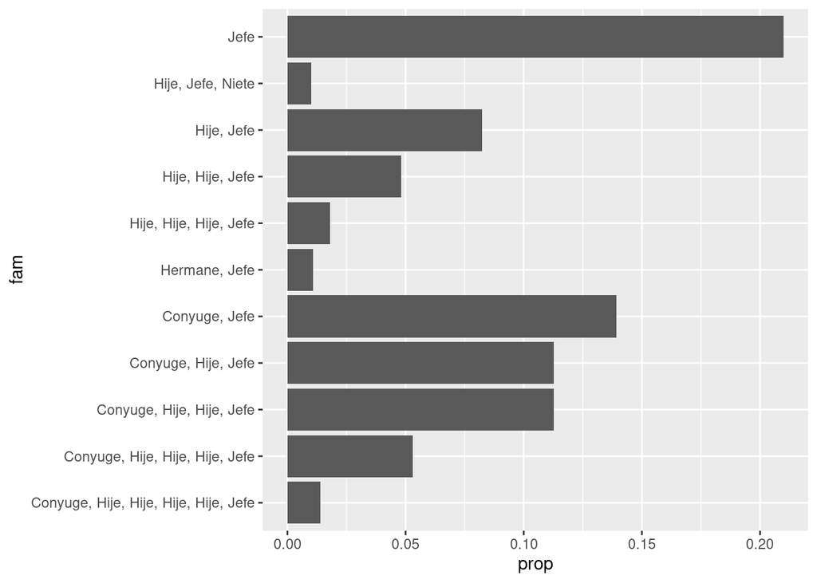

```r
familias_casos %>% filter(prop>1/100) %>% ggplot(aes(y=fam,x=prop)) + geom_col()
```

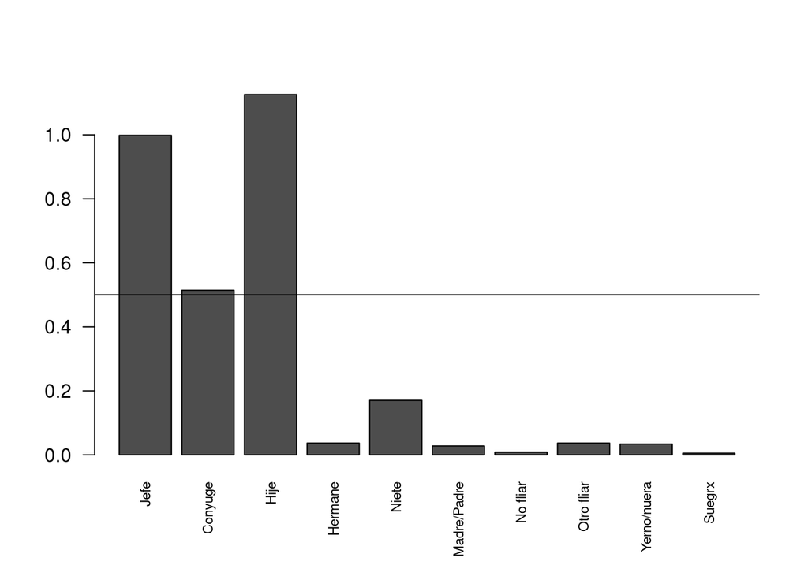

```r
familia_a_fila <- function(fami){

}


famlvls <- familias_casos$fam %>% str_split(', ') %>% unlist %>% unique

tabifam <- familias_casos$fam %>% str_split(', ') %>% lapply(factor,levels = famlvls) %>% lapply(table) %>% do.call(rbind,.)

cuentas <- familias_casos$prop %*% tabifam

barplot(cuentas,las=2,cex.names = .7)
abline(h=0.5)
```